# Assignment 8: Visualization - Making a bar race

*How to do it?*:

- Open the Rmarkdown file of this assignment (link) in Rstudio.
- Right under each **question**, insert a code chunk (you can use the hotkey `Ctrl + Alt + I` to add a code chunk) and code the solution for the question.
- `Knit` the rmarkdown file (hotkey: `Ctrl + Alt + K`) to export an html.
- Publish the html file to your Githiub Page.

*Submission*: Submit the link on Github of the assignment to Canvas

```r
#install.packages('gganimate')
#install.packages('gifski')
```

2. Using the `Adult Census Income` data, make an animation using `geom_bar` and `transition_states`.

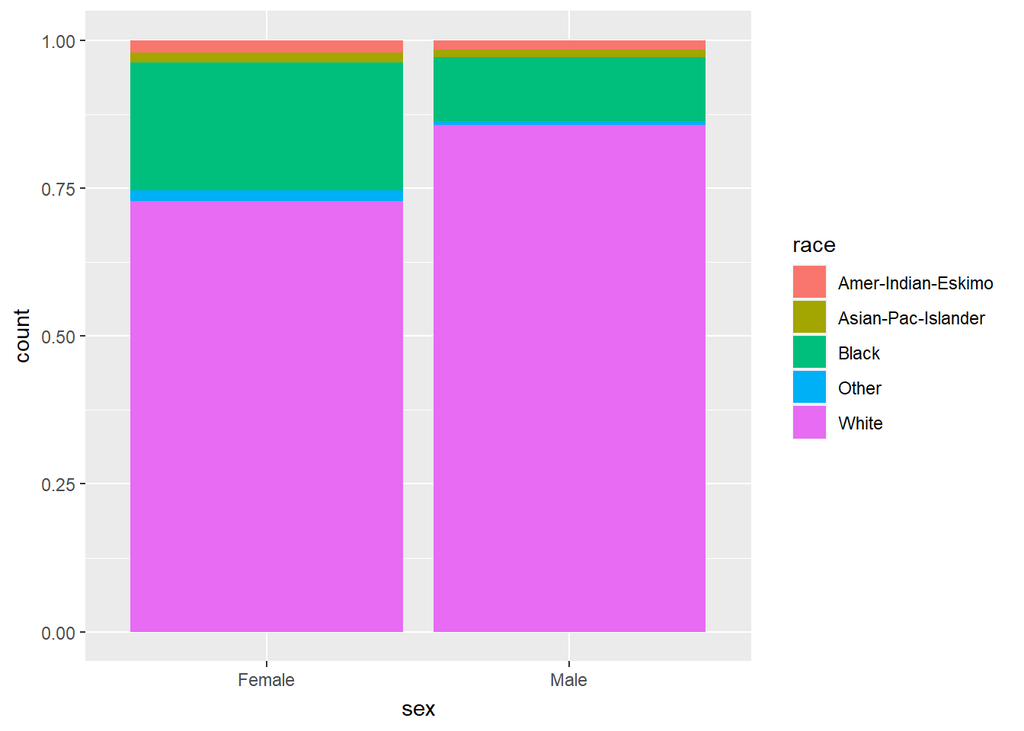

```r
library(tidyverse)
library(gganimate)
adult_df <- read_csv('adult_census_missing.csv')

adult_df %>%
  filter(sex == "Male" |
         sex == "Female") %>%
ggplot(aes(x = sex, fill=race)) +
  geom_bar(position = 'fill') +
  transition_states(education)
```

3. Use the WHO’s dataset at [this link](https://covid19.who.int/WHO-COVID-19-global-data.csv). Make a top-10 bar race by months between countries on the number of deaths by Covid 19 in 2021.

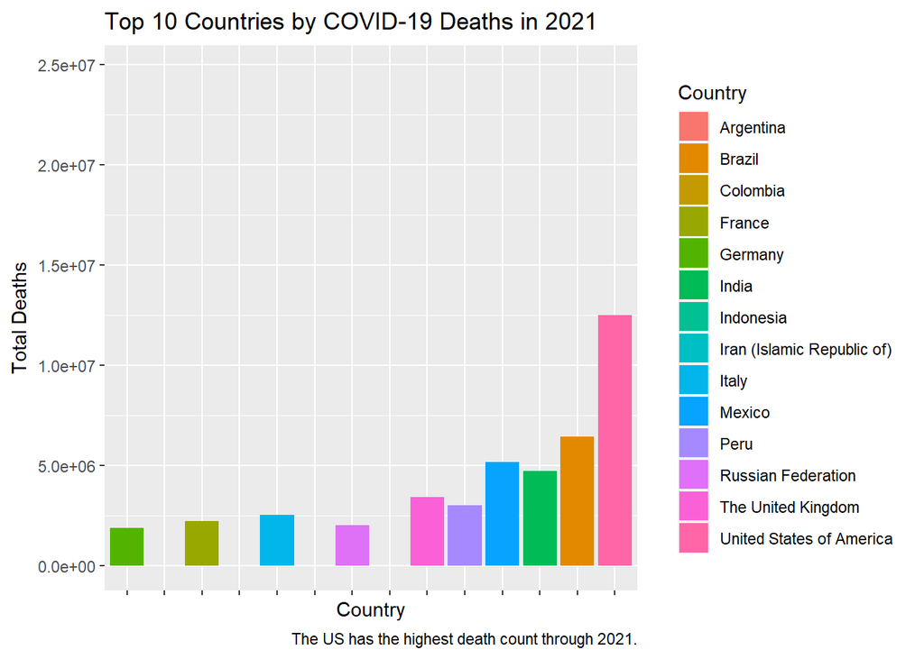

```r
who_df <- read_csv('https://covid19.who.int/WHO-COVID-19-global-data.csv')

who_df$month <- month(who_df$Date_reported)

top_countries <- who_df %>%
  filter(year(who_df$Date_reported) == 2021) %>%
  group_by(Country, month) %>%
  summarize(Total_Country_Deaths = sum(Cumulative_deaths)) %>%
  ungroup() %>%
  arrange(desc(Total_Country_Deaths)) %>%
  group_by(month) %>%
  top_n(10)

top_countries %>%
  ggplot(aes(x = fct_reorder(Country, Total_Country_Deaths), y = Total_Country_Deaths, fill = Country)) +
  geom_bar(stat = "identity") +
  labs(
    title = "Top 10 Countries by COVID-19 Deaths in 2021",
    x = "Country",
    y = "Total Deaths",
    caption = "The US has the highest death count through 2021."
  ) +
  transition_states(month, transition_length = 2, state_length = 1) +
  theme(axis.text.x = element_blank())
```

4. Make a bar race using a dataset of your own interest. You may use the dataset that we use in class (https://covidtracking.com/data/download/all-states-history.csv) but you should make a different bar racev from ones in the slides.

[figure not shown]

```r
covid_tracking_df <- read_csv('https://covidtracking.com/data/download/all-states-history.csv')
top_5 <- c('NJ', 'FL', 'AZ', 'GA', 'OH')

covid_tracking_df_grouped <- covid_tracking_df %>%
  filter(state %in% top_5) %>%
  group_by(state, date) %>%
  summarize(hospital = sum(hospitalizedCumulative, na.rm=TRUE)) %>%
  ungroup() %>%
  arrange(desc(hospital)) %>%
  group_by(date)

covid_tracking_df_grouped %>%
  ggplot(aes(x = fct_reorder(state, hospital), y = hospital , fill = state)) +
  geom_bar(stat = "identity") +
  labs(
    title = "Top 5 States by Hospitalizations (2020-2021)",
    x = "State",
    y = "Total Hospitalizations",
    caption = "Florida had the highest number of hospitalizations."
  ) +
  transition_states(date, transition_length = 2, state_length = 1)
```